# Part 1: Preprocessing scRNA-seq using Seurat - Launonen et al., 2024

```r
# load required libraries and set working directory
require(dplyr)
library(purrr)
require(Seurat)
require(monocle3)
require(data.table)

setwd('/Users/abba5hahroze/Desktop/Rayca/')

options(repr.plot.width=12, repr.plot.height=7)
```

```r
# load seuratwrappers and install if not found
if (!require(SeuratWrappers)) remotes::install_github('satijalab/seurat-wrappers')
```

```r
# read in the metadata
metadata <- fread('counts/metadata.tsv.gz', sep='\t')
```

#### Here, I'm choosing to focus on cytotoxic T cells and macrophages as they were the focus on the article. The authors show that T cells gain an exhausted phenotype after chemotherapy and relocate spatially. Hopefully pseudotime of the treatment stages will help to identify markers associated with change.

```r
# read in the counts and create Seurat object
object <- CreateSeuratObject(Read10X(data.dir='counts', gene.column=1), meta.data=metadata)
object <- object %>% subset(cells=metadata[cell_type %chin% c('Tem/Trm cytotoxic T cells', 'Macrophages'), cell_name])
```

#### Typically, I would identify doublets and filter but will leave that out for now. Common metrics are percent mito and percent ribo. This represents the fraction of a cells measured transcriptome that mapped to mitochondrial or ribosomal rna. You can also look at hemoglobin percentages in case cells were contaminated during biopsy, but will also leave that out for now.

```r
object[['percent.mt']] <- PercentageFeatureSet(object, pattern='^MT-')
object[['percent.rb']] <- PercentageFeatureSet(object, pattern='^RP[LS]')
```

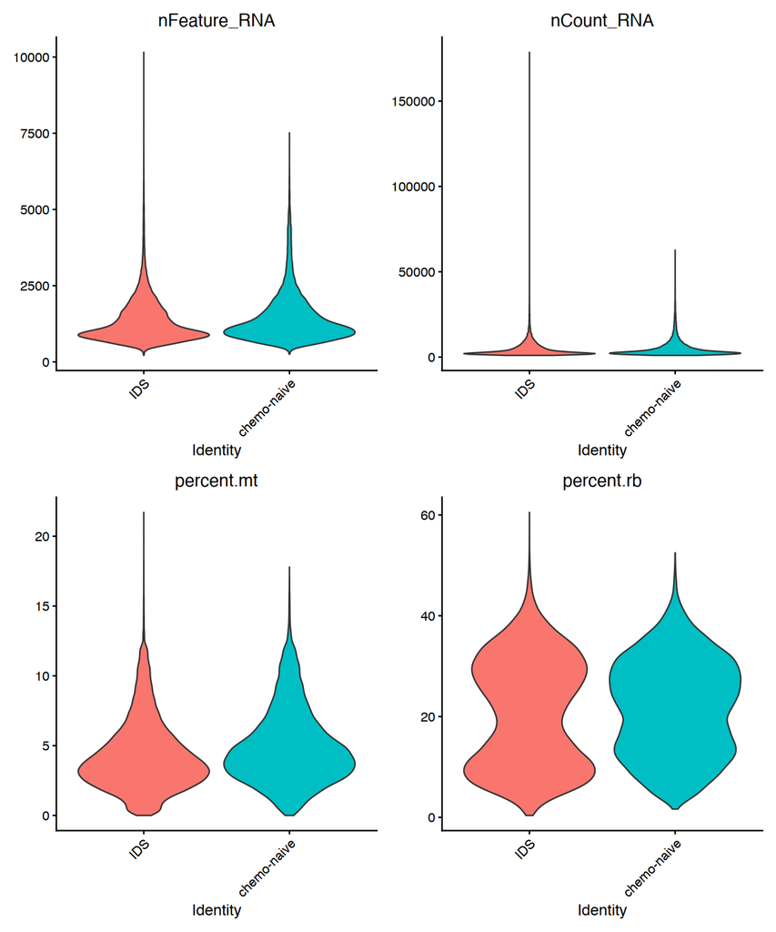

```r
options(repr.plot.width=10, repr.plot.height=12)

object %>% VlnPlot(
    features=c('nFeature_RNA', 'nCount_RNA', 'percent.mt', 'percent.rb'),
    ncol=2, pt.size=0, group.by='treatment_stage', log=FALSE
)
```

#### Overall, the data are relatively cleaner than expected. I expected cells with higher MT percentages. The RB percentages don't show anything concerning but are higher than expected. The 10X chemistry is older as well which means number of genes detected might be lower. Based on these violin plots, we can choose appropriate cutoffs.

```r
object <- object %>% subset(subset=nCount_RNA %between% c(300, 5e4) & nFeature_RNA %between% c(500, 6000) & percent.mt < 15)
```

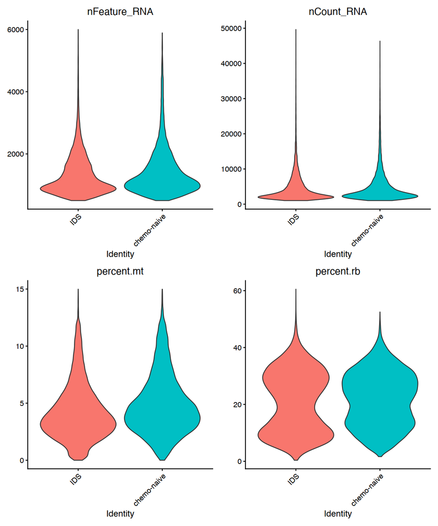

```r
options(repr.plot.width=10, repr.plot.height=12)

object %>% VlnPlot(
    features=c('nFeature_RNA', 'nCount_RNA', 'percent.mt', 'percent.rb'),
    ncol=2, pt.size=0, group.by='treatment_stage', log=FALSE
)
```

#### After preprocessing, I normalize the data per cell and log transform. The default for variable gene selection is 2000 but I am increasing to 3000 because we have more genes in the reference. The dataset is diseased and contains case/control so modeling more genes downstream may be helpful.

```r
object <- object %>% NormalizeData() %>% FindVariableFeatures(nfeatures=3000)
```

```
Normalizing layer: counts

Finding variable features for layer counts
```

#### Visualize the top variable genes to make sure we don't have pseudogenes or MT/RB genes in the list.

```
When using repel, set xnudge and ynudge to 0 for optimal results

Warning message in scale_x_log10():
“log-10 transformation introduced infinite values.”
Warning message:
“ggrepel: 3 unlabeled data points (too many overlaps). Consider increasing max.overlaps”
```

[figure not shown]

```r
options(repr.plot.width=10, repr.plot.height=6)

top <- head(VariableFeatures(object), 20)
object %>% VariableFeaturePlot() %>% LabelPoints(points=top, repel=TRUE)
```

#### Scale and perform dimension reduction.

```r
object <- object %>% ScaleData() %>% RunPCA()
```

```
PC_ 1
Positive:  TRBC2, CCL5, CD7, NKG7, TRBC1, IL32, ITM2A, CD3G, GZMA, GZMK
	   CD8B, TUBA4A, SH2D1A, CTSW, HMGB2, KLRD1, GZMH, IKZF3, AC092580.4, PRF1
	   GZMM, CD69, LTB, CD52, LAG3, SAMD3, CD27, CORO1A, CMC1, KLRB1
Negative:  TYROBP, FCER1G, PSAP, CST3, NPC2, FTL, CTSB, HLA-DRA, SOD2, GRN
	   CD63, PLAUR, CTSL, SAT1, GPX1, APOE, CTSD, CTSZ, C1QA, FCGRT
	   C1QC, CTSS, C1QB, LYZ, MARCKS, CXCL8, HLA-DRB1, IER3, CREG1, APOC1
PC_ 2
Positive:  LYVE1, CSF1R, VSIG4, STAB1, C1orf162, MS4A6A, CYBB, MNDA, FCGR1A, LGALS9
	   SAMHD1, AIF1, FCGR3A, COTL1, MPEG1, CLEC10A, PYCARD, TREM2, COLEC12, GPR34
	   ACTB, HK3, SCIMP, LST1, VAMP5, VAMP8, RASSF4, MARCH1, SDC3, NAIP
Negative:  SLC7A11, CXCL8, SERPINB2, CYP1B1, CXCL3, TXN, CXCL1, C15orf48, EREG, TNFAIP6
	   SOD2, CXCL2, TXNRD1, RSAD2, CCL20, ITGB8, MGST1, MMP9, IL1B, WTAP
	   CCL3, SNX10, PTGS2, AQP9, KYNU, LRP12, ATP2B1, BASP1, IL6, SQSTM1
PC_ 3
Positive:  CXCL5, THBS1, S100A8, PTGES, CD300E, VCAN, TIMP1, CTB-61M7.2, PID1, MCEMP1
	   SEMA6B, SLC44A1, CCL2, S100A9, DMXL2, SDC2, MET, LINC01272, HCK, LACC1
	   LILRA1, NAMPT, SLC25A37, C3AR1, CFP, LRRC25, CD14, MS4A7, KYNU, SLC43A2
Negative:  APOC1, C1QA, APOE, CD74, HLA-DPA1, HLA-DQB1, RGS1, HLA-DQA1, HLA-DPB1, C1QB
	   IFI27, C1QC, HLA-DRB5, HLA-DMA, HLA-DRB1, SPP1, IFI6, LGALS3BP, TREM2, RASGRP3
	   PELI1, KLF4, GPNMB, LMNA, HLA-DRA, GADD45B, ID2, SDS, LY86, IFITM3
PC_ 4
Positive:  MKI67, BIRC5, UBE2C, TOP2A, ASPM, KIAA0101, AURKB, TYMS, GTSE1, NUSAP1
	   DLGAP5, CEP55, TPX2, RRM2, CDKN3, CDK1, CCNB2, CKAP2L, CDT1, CDCA5
	   CKS1B, KIF2C, CDC20, STMN1, CENPA, SGO1, CENPF, CDCA8, CCNA2, HJURP
Negative:  FOSB, KLF4, FOS, GADD45B, GGTA1P, SEPP1, AIF1, LMNA, NR4A2, SGK1
	   MS4A6A, ZFP36, GLUL, EGR1, FCGR3A, C1QA, DUSP1, PLTP, RGCC, C1orf162
	   ZNF331, ZNF385A, MAFF, LST1, RGS2, FCGR2B, TYROBP, RNASE1, FOLR2, VSIG4
PC_ 5
Positive:  RSAD2, LYVE1, FTLP3, CD36, GM2A, SDC3, GPNMB, CMPK2, CSF1, PALLD
	   TXNRD1, PCOLCE2, TM4SF1, HS3ST2, CFD, MARCH1, LIPA, CR1, COLEC12, TDRD3
	   MMP1, SERPINE2, DPP4, CCL18, LRP12, HK3, SLC7A8, SPP1, TCN2, NAIP
Negative:  SDS, OLR1, CXCL5, THBS1, IFI30, GADD45B, PTGES, MT2A, SGK1, KLF4
	   LMNA, SAT1, RGS1, PID1, VEGFA, JUNB, CD300E, G0S2, AREG, SLC16A10
	   MT-RNR1, GPR183, FCER1G, MCEMP1, FOS, TIMP1, SLC44A1, DUSP1, IL1R2, THBD
```

#### Calculate 95% cumulative variance for pca dimensions. I could correlate dimensions with covariates to see if certain ones need to be removed but choosing to leave that out here. The data are clean and filtered, batch correction is performed and so removing dimensions completely should be unnecessary for now.

```r
pca_stdev <- object[['pca']]@stdev

pca_var <- pca_stdev^2
pca_var_exp <- pca_var / sum(pca_var)

cum_var <- cumsum(pca_var_exp)
num_dims <- which(cum_var >= 0.95)[1]
```

#### Performing UMAP reduction to generate embeddings for visualization. I'm doing this on the PCA dimensions which are not batch corrected.

```r
object <- object %>% RunUMAP(dims=seq(num_dims), reduction='pca')
```

[output not shown]

#### Interesting to note here, in terms of cell type specific grouping, there is minimal batch effect. The cells are grouping as either macrophages or t cells with their respective populations. However, the within cell type batch effect is more prominent, especially in the macrophage population. Due to the stronger batch effect, the macrophage population is not as densly grouped.

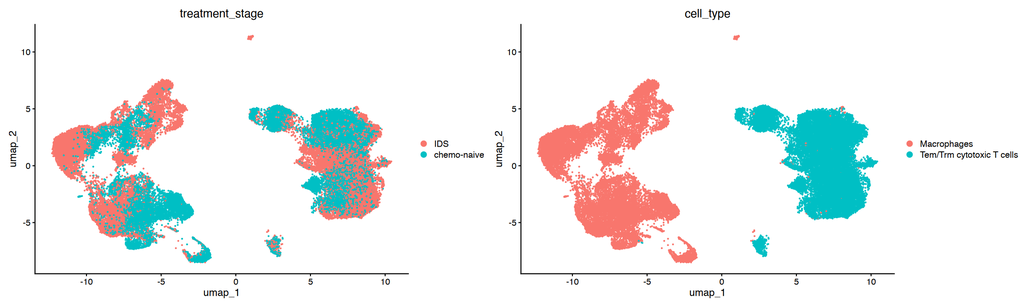

```r
options(repr.plot.width=20, repr.plot.height=6)
p1 <- DimPlot(object, reduction='umap', group.by='treatment_stage')
p2 <- DimPlot(object, reduction='umap', group.by='cell_type')
p1 + p2
```

#### I am choosing to perform batch correction with Harmony as it performs well in benchmarking, is easy to use, and offers flexibility to the strength of correction.

```r
object <- object %>% harmony::RunHarmony(group.by.vars='publication_sample_code_final')
```

```
Transposing data matrix

Initializing state using k-means centroids initialization

Warning message:
“Quick-TRANSfer stage steps exceeded maximum (= 2414050)”
Warning message:
“Quick-TRANSfer stage steps exceeded maximum (= 2414050)”
Harmony 1/10

Harmony 2/10

Harmony 3/10

Harmony 4/10

Harmony 5/10

Harmony converged after 5 iterations
```

```r
object <- object %>% RunUMAP(dims=seq(num_dims), reduction='harmony')
```

[output not shown]

#### After batch correction, both cell types look much cleaner. The random sub-populations of macrophages have disappeared and the spread of cells colored by treatment stage is more uniform. Let's see if we can model a trajectory.

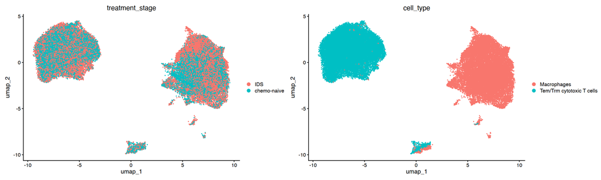

```r
options(repr.plot.width=20, repr.plot.height=6)
p1 <- DimPlot(object, reduction='umap', group.by='treatment_stage')
p2 <- DimPlot(object, reduction='umap', group.by='cell_type')
p1 + p2
```

```r
saveRDS(object, 'rayca_immune_singlecell_seurat_object.rds')
```